# Bandwidth Selection

[video not shown]

Video 1 : Bandwidth Selection

# Module Description

This module contains functions for automatic bandwidth selection to calibrate basic GW regression (bw.gwr), generalised GWR model (bw.ggwr), GW Principal Components Analysis (bw.gwpca), and GW Discriminant Analysis (bw.gwda)

# Argument

The arguments were taken from Gollini et al.[1]

| Argument | bw.gwr | bw.ggwr | bw.gwda | bw.gwpca |
| --- | --- | --- | --- | --- |
| `Dependient` | ✔ | ✔ | ✔ | x |
| `Independient` | ✔ | ✔ | ✔ | x |
| `Family` | x | ✔ | x | x |
| `Approach` | ✔ | ✔ | x | x |
| `Kernel` | ✔ | ✔ | ✔ | ✔ |
| `Power` | ✔ | ✔ | ✔ | ✔ |
| `Theta` | ✔ | ✔ | ✔ | ✔ |
| `Longlat` | ✔ | ✔ | ✔ | ✔ |
| `Adaptative` | ✔ | ✔ | ✔ | ✔ |
| `Cov.gw` | x | x | ✔ | x |
| `Prior.gw` | x | x | ✔ | x |
| `Mean.gw` | x | x | ✔ | x |
| `wqda` | x | x | ✔ | x |
| `Variables` | x | x | x | ✔ |
| `Robust` | x | x | x | ✔ |

`Dependient`: Dependent variable of the regression model

`Independient`: Independent(s) variable(s) of the regression model.

`Family`: a description of the model’s error distribution and link function, which can be “poisson” or “binomial”.

`Approach`: specified by CV for cross-validation approach or by Akaike Information Criterion corrected (AICc) approach

`Kernel`: A set of five commonly used kernel functions;

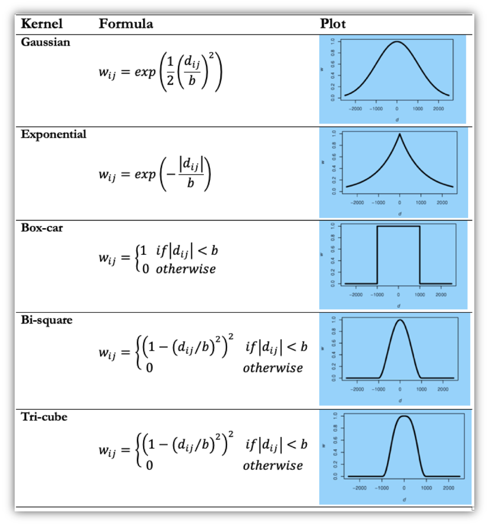

Figure 1. Five kernel functions $w_{ij}$ is the j-th element of the diagonal of the matrix of geographical weights W($u_i$,$v_i$), and $d_{ij}$ is the distance between observations i and j, and b is the bandwidth.

`Power (Minkowski distance)`: the power of the Minkowski distance (p=1 is manhattan distance, p=2 is euclidean distance).

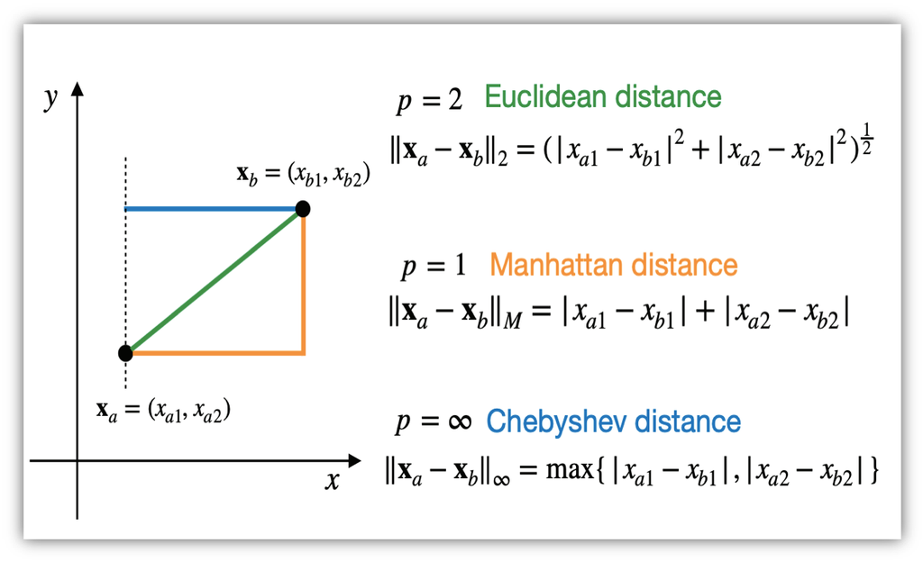

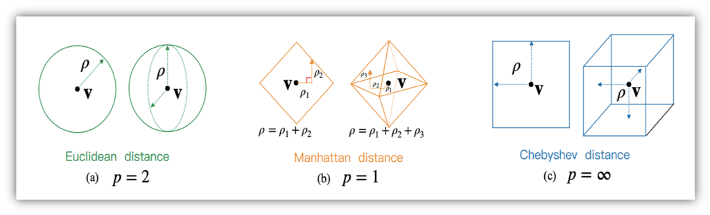

Figure 2. Minkowski distance

`Theta (Angle in radians)`: an angle in radians to rotate the coordinate system, default is 0

`longlat`: if TRUE, great circle distances will be calculated

`Adaptive`:If TRUE, find an adaptive kernel with a bandwidth proportional to the number of nearest neighbors (i.e. adaptive distance); otherwise, find a fixed kernel (bandwidth is a fixed distance)

`Cov.gw`:if TRUE, localised variance-covariance matrix is used for GW discriminant analysis; otherwise, global variance-covariance matrix is used

`Prior.gw`: if TRUE, localised prior probability is used for GW discriminant analysis; otherwise, fixed prior probability is used

`Mean.gw`: if true, localised mean is used for GW discriminant analysis; otherwise, global mean is used

`wqda` : if TRUE, a weighted quadratic discriminant analysis will be applied; otherwise a weighted linear discriminant analysis will be applied

`Variables`: a vector of variable names to be evaluated

`Robust`: if TRUE, robust GWPCA will be applied; otherwise basic GWPCA will be applied

# Value

Returns the adaptive or fixed distance bandwidth.

A critical issue is deciding between two types of spatial kernels: fixed kernels and adaptive kernels. A fixed kernel, by definition, uses a fixed bandwidth to define a region around all regression points. The distance to a given point determines the extent of the kernel, which is identical at any point in space. An adaptive kernel defines a region around points by using varying bandwidth. The number of nearest neighbors from a given regression point determines the kernel’s size. Where the data is sparse, the kernels have larger bandwidths.

# References

[1] Gollini, I., Lu, B., Charlton, M., Brunsdon, C., & Harris, P. (2015). GWmodel: An R Package for Exploring Spatial Heterogeneity Using Geographically Weighted Models. *Journal of Statistical Software*, 63(17), 1–50. https://doi.org/10.18637/jss.v063.i17